# Statistical Modeling of Iron County Property Values

Ryan McMurray, Melanie Jensen, Viniccius Florindo Coelho

## The Problem

- Property values are only captured at the **point of sale**
- Between sales, assessors must estimate value manually — no data-driven basis
- Estimates are inconsistently applied and **difficult to defend in court**
- The result: property tax assessments that are arbitrary and legally vulnerable

## Our Approach

- **Phase 1 — Understanding the Market:** Identify what drives property value and uncover natural sub-markets
- **Phase 2 — Building the Model:** Predict property value from numerical and non-numerical features
- **Phase 3 — The Application:** A defensible, data-backed value estimate tool for assessors

# Current Insights (Phase 1)

## The Standard vs. The Luxury

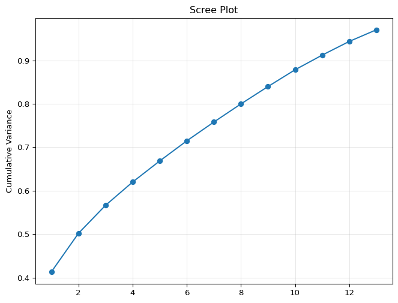

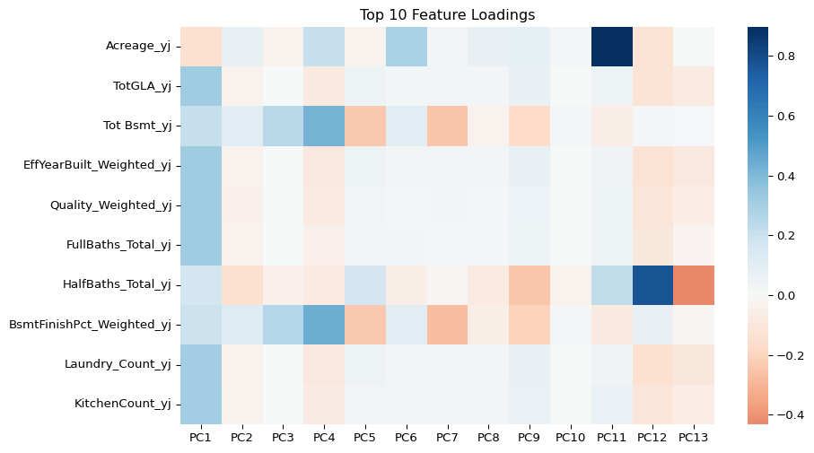

## Sub-Markets

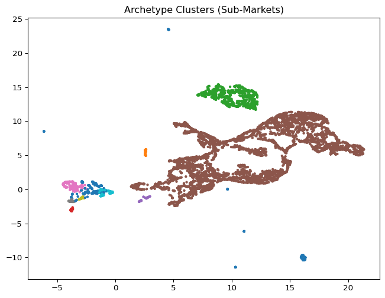

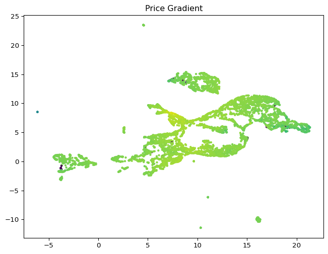

# Current Insights (Phase 2)

## Prices After Stabalization

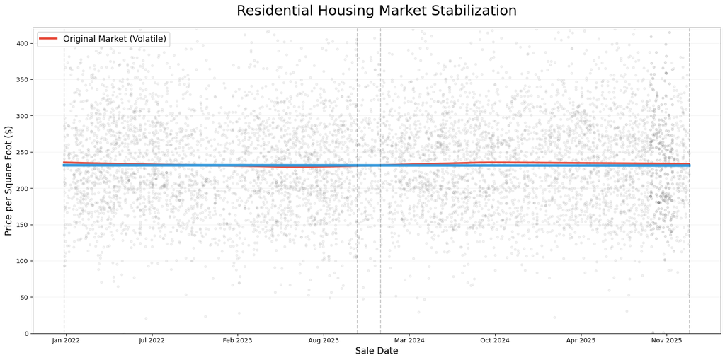

## The Current Model

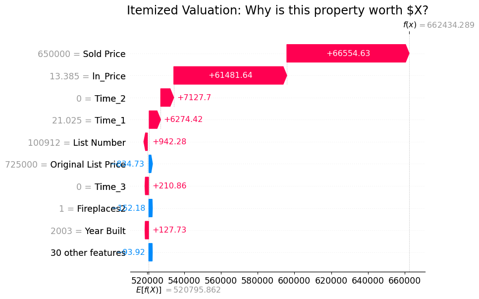

# The Application

## Vision & Architecture

Deployment direction discussed in our most recent stakeholder meeting:

- Beta Version: Scoped to the Commissioner’s Office only, preserving data confidentiality without requiring public-facing infrastructure.
- Future Version: The office may explore opening access to the public, which would require dedicated data centers and formal security protocols to protect sensitive parcel data.

## Next Steps

- **Phase 2:** Complete model development and validation (target: R² ≥ 0.90)
- **Phase 3:** Complete UI development for assessor-facing application
- **Delivery:** Hand off to the Commissioner’s Office for beta testing